# IE 360 HW1

Ali Can Şahin

2018402189

13/04/2022

# Introduction

The main point of this homework is the getting an understanding about the estate market in Turkey. In this analysis 4 different type of data were examined and plotted to be able to understand the behaviours of the components visually. These data are the number of houses that are sold, interest rates of banks in estate loans, cost of living index of Turkish people and search volume for houses in Turkey. At the end of the report correlation plot of the variables is also shown to visualize their relationships better.

# Library Installiation

```r
setwd("C:/Users/alica/OneDrive/Masaüstü/ali belgeler/BOUN/3.Sınıf/2.DÖNEM/IE 360/HW1")
#install.packages("ggplot2")
#install.packages("data.table")
#install.packages("corrplot")
library(ggplot2)
library(data.table)
#install.packages("https://cran.r-project.org/src/contrib/Archive/lubridate/lubridate_1.7.4.tar.gz",repos=NULL)
```

# Number of Houses Sold In Years

To proceed, we should first understand how many houses are sold in different time periods and how did change. Therefore appropriate data are collected and plotted. Our data starts from 01-2016 and end at 12-2021. It was thought that, it would be meaningless to analyse year 2022 because there are not enough data.

```r
library(lubridate)
sold_house_data = read.csv("toplam_konut_satış.csv")
setDT(sold_house_data)
sold_house_data[,year_of_date:=year(ym(tarih))]
sold_house_data[,month_of_date:=month(ym(tarih))]
sold_house_data
yearly_sold = sold_house_data[,list(total = sum(toplam_satış)),list(year_of_date)]
yearly_sold
```

| tarih | toplam_satış | year_of_date | month_of_date |
| --- | --- | --- | --- |
| 2016-01 | 40077 | 2016 | 1 |
| 2016-02 | 47409 | 2016 | 2 |
| 2016-03 | 52374 | 2016 | 3 |
| 2016-04 | 46908 | 2016 | 4 |
| 2016-05 | 56043 | 2016 | 5 |
| 2016-06 | 49354 | 2016 | 6 |
| 2016-07 | 37829 | 2016 | 7 |
| 2016-08 | 53784 | 2016 | 8 |
| 2016-09 | 50972 | 2016 | 9 |
| 2016-10 | 61677 | 2016 | 10 |
| 2016-11 | 63467 | 2016 | 11 |
| 2016-12 | 71792 | 2016 | 12 |
| 2017-01 | 44235 | 2017 | 1 |
| 2017-02 | 45215 | 2017 | 2 |
| 2017-03 | 56376 | 2017 | 3 |
| 2017-04 | 51988 | 2017 | 4 |
| 2017-05 | 52976 | 2017 | 5 |
| 2017-06 | 45433 | 2017 | 6 |
| 2017-07 | 53949 | 2017 | 7 |
| 2017-08 | 56498 | 2017 | 8 |
| 2017-09 | 70019 | 2017 | 9 |
| 2017-10 | 56994 | 2017 | 10 |
| 2017-11 | 59354 | 2017 | 11 |
| 2017-12 | 66661 | 2017 | 12 |
| 2018-01 | 44363 | 2018 | 1 |
| 2018-02 | 43713 | 2018 | 2 |
| 2018-03 | 50701 | 2018 | 3 |
| 2018-04 | 47534 | 2018 | 4 |
| 2018-05 | 55502 | 2018 | 5 |
| 2018-06 | 57064 | 2018 | 6 |
| ... | ... | ... | ... |
| 2019-07 | 38931 | 2019 | 7 |
| 2019-08 | 40634 | 2019 | 8 |
| 2019-09 | 51393 | 2019 | 9 |
| 2019-10 | 50181 | 2019 | 10 |
| 2019-11 | 48909 | 2019 | 11 |
| 2019-12 | 75480 | 2019 | 12 |
| 2020-01 | 36040 | 2020 | 1 |
| 2020-02 | 37303 | 2020 | 2 |
| 2020-03 | 34089 | 2020 | 3 |
| 2020-04 | 14848 | 2020 | 4 |
| 2020-05 | 16860 | 2020 | 5 |
| 2020-06 | 58632 | 2020 | 6 |
| 2020-07 | 67937 | 2020 | 7 |
| 2020-08 | 52123 | 2020 | 8 |
| 2020-09 | 41376 | 2020 | 9 |
| 2020-10 | 36976 | 2020 | 10 |
| 2020-11 | 36658 | 2020 | 11 |
| 2020-12 | 36898 | 2020 | 12 |
| 2021-01 | 22268 | 2021 | 1 |
| 2021-02 | 24737 | 2021 | 2 |
| 2021-03 | 33365 | 2021 | 3 |
| 2021-04 | 29212 | 2021 | 4 |
| 2021-05 | 18204 | 2021 | 5 |
| 2021-06 | 40092 | 2021 | 6 |
| 2021-07 | 32672 | 2021 | 7 |
| 2021-08 | 42639 | 2021 | 8 |
| 2021-09 | 43967 | 2021 | 9 |
| 2021-10 | 41914 | 2021 | 10 |
| 2021-11 | 55706 | 2021 | 11 |
| 2021-12 | 76747 | 2021 | 12 |

| year_of_date | total |
| --- | --- |
| 2016 | 631686 |
| 2017 | 659698 |
| 2018 | 651572 |
| 2019 | 511682 |
| 2020 | 469740 |
| 2021 | 461523 |

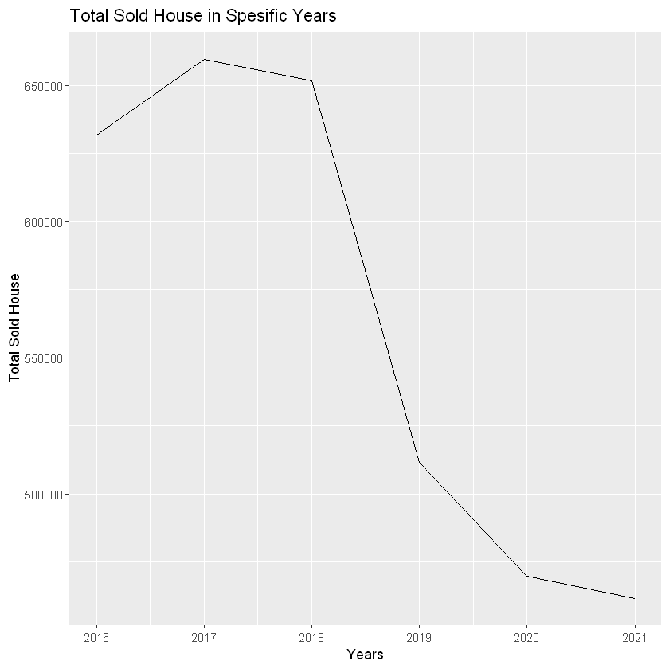

```r
ggplot(yearly_sold,aes(x=year_of_date,y= total)) +
geom_line() + ylab("Total Sold House") + xlab("Years") + ggtitle("Total Sold House in Spesific Years")
```

As it can be seen from the graph there is a continous decrease after year 2017. To find out the reason it would be better to check boxplot and monthly sellings of the houses.

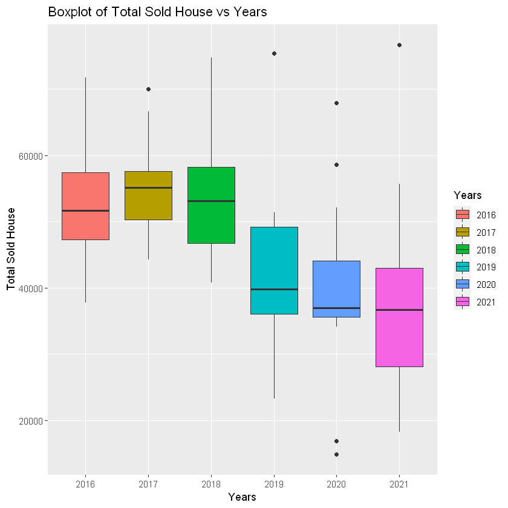

```r
ggplot(sold_house_data,aes(x=factor(year_of_date),y=toplam_satış)) + geom_boxplot(aes(fill = factor(year_of_date)))+ labs(fill="Years")+
xlab("Years") + ylab("Total Sold House") + ggtitle("Boxplot of Total Sold House vs Years")
```

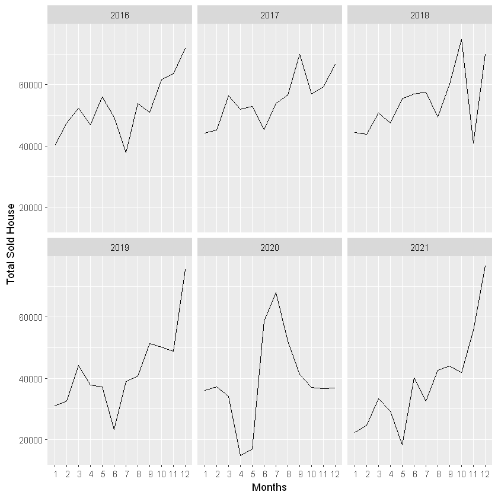

```r
ggplot(sold_house_data,aes(x=month_of_date,y=toplam_satış)) +
geom_line() + facet_wrap(~year_of_date) + scale_x_discrete(limits = c(1:12))+xlab("Months") + ylab("Total Sold House")
```

Boxplots show us that average numbers of sold houses first increase and after 2017, it decrease. It is consistent with our first plot. However, there are some range differences and outliers. In some years differences between min and max number of sellings are various. To understand this situation and its reasons third plot is plotted.

# Interest Rates of Bank Loans

The decrease in the number of houses after 2017 should be examined. After this year it seems there is a decreaing trend. One of the reason of this situaiton can be interest rates of banks in their loans. People who want to buy a new house can give up because of the high interest rates. Therefore in this part of the report interest rates will be examined.

```r
konut_kredi_faiz = read.csv("konut_kredi_faiz.csv")
setDT(konut_kredi_faiz )
konut_kredi_faiz[,year_of_date := year(ym(tarih))]
konut_kredi_faiz[,month_of_date := month(ym(tarih))]
konut_kredi_faiz
```

| tarih | faiz_oran | year_of_date | month_of_date |
| --- | --- | --- | --- |
| 2016-01 | 14.27 | 2016 | 1 |
| 2016-02 | 14.45 | 2016 | 2 |
| 2016-03 | 14.45 | 2016 | 3 |
| 2016-04 | 14.33 | 2016 | 4 |
| 2016-05 | 13.96 | 2016 | 5 |
| 2016-06 | 13.84 | 2016 | 6 |
| 2016-07 | 13.67 | 2016 | 7 |
| 2016-08 | 12.86 | 2016 | 8 |
| 2016-09 | 12.09 | 2016 | 9 |
| 2016-10 | 12.12 | 2016 | 10 |
| 2016-11 | 11.69 | 2016 | 11 |
| 2016-12 | 11.42 | 2016 | 12 |
| 2017-01 | 11.45 | 2017 | 1 |
| 2017-02 | 11.38 | 2017 | 2 |
| 2017-03 | 11.06 | 2017 | 3 |
| 2017-04 | 11.28 | 2017 | 4 |
| 2017-05 | 11.55 | 2017 | 5 |
| 2017-06 | 11.72 | 2017 | 6 |
| 2017-07 | 12.02 | 2017 | 7 |
| 2017-08 | 12.49 | 2017 | 8 |
| 2017-09 | 12.87 | 2017 | 9 |
| 2017-10 | 13.05 | 2017 | 10 |
| 2017-11 | 13.12 | 2017 | 11 |
| 2017-12 | 13.52 | 2017 | 12 |
| 2018-01 | 14.14 | 2018 | 1 |
| 2018-02 | 14.68 | 2018 | 2 |
| 2018-03 | 14.79 | 2018 | 3 |
| 2018-04 | 14.83 | 2018 | 4 |
| 2018-05 | 13.88 | 2018 | 5 |
| 2018-06 | 13.10 | 2018 | 6 |
| ... | ... | ... | ... |
| 2019-07 | 21.06 | 2019 | 7 |
| 2019-08 | 14.15 | 2019 | 8 |
| 2019-09 | 12.98 | 2019 | 9 |
| 2019-10 | 13.12 | 2019 | 10 |
| 2019-11 | 12.96 | 2019 | 11 |
| 2019-12 | 12.69 | 2019 | 12 |
| 2020-01 | 11.88 | 2020 | 1 |
| 2020-02 | 11.43 | 2020 | 2 |
| 2020-03 | 11.40 | 2020 | 3 |
| 2020-04 | 11.72 | 2020 | 4 |
| 2020-05 | 11.23 | 2020 | 5 |
| 2020-06 | 9.30 | 2020 | 6 |
| 2020-07 | 9.11 | 2020 | 7 |
| 2020-08 | 11.09 | 2020 | 8 |
| 2020-09 | 14.16 | 2020 | 9 |
| 2020-10 | 15.07 | 2020 | 10 |
| 2020-11 | 15.68 | 2020 | 11 |
| 2020-12 | 18.19 | 2020 | 12 |
| 2021-01 | 18.39 | 2021 | 1 |
| 2021-02 | 17.99 | 2021 | 2 |
| 2021-03 | 17.74 | 2021 | 3 |
| 2021-04 | 18.13 | 2021 | 4 |
| 2021-05 | 17.84 | 2021 | 5 |
| 2021-06 | 17.90 | 2021 | 6 |
| 2021-07 | 17.93 | 2021 | 7 |
| 2021-08 | 17.86 | 2021 | 8 |
| 2021-09 | 17.90 | 2021 | 9 |
| 2021-10 | 17.82 | 2021 | 10 |
| 2021-11 | 17.10 | 2021 | 11 |
| 2021-12 | 17.31 | 2021 | 12 |

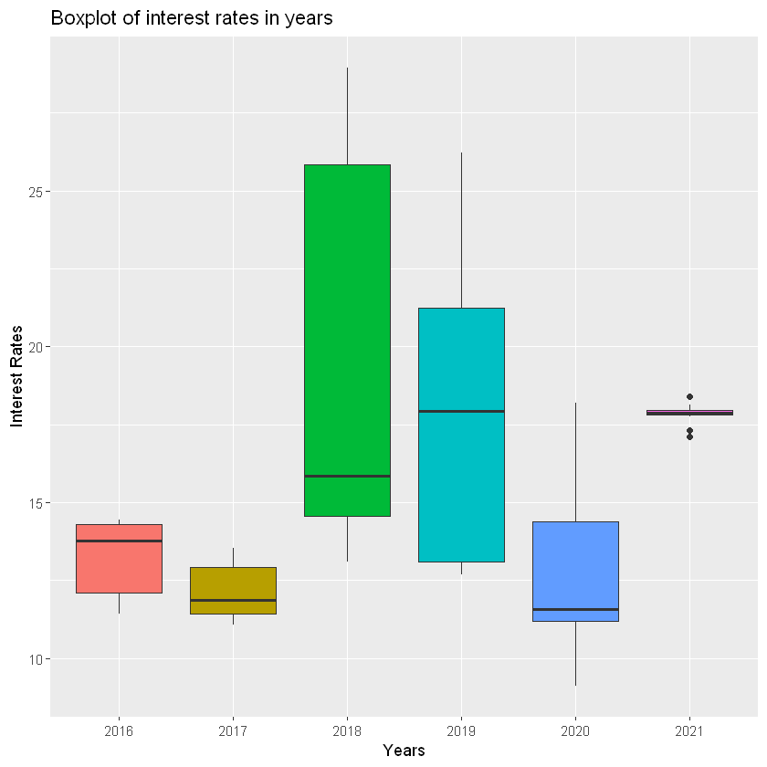

```r
ggplot(konut_kredi_faiz, aes(x=factor(year_of_date),y = faiz_oran)) + geom_boxplot(aes(fill = factor(year_of_date)))+
labs(x="Years",y="Interest Rates",title="Boxplot of interest rates in years") +theme(legend.position = "none")
```

The relationship between number of sold houses and interest rates is expected to be reversed. From these plots, it can actually be proved. Average of the interest rate first decrease and then increase. Only assumption is 2020. Despite huge decrease in average interest rates, less houses are sold totally. Again, it can assumed that, the reason is Covid-19. Also, the IQR values of the years 2018 and 2019 are also interesting. Especially in 2018 there is a huge variance in interest rates. It can be because of the currency crisis that occurs in Turkey. It seems that these huge variances also effected the selling numbers. In the period between 2018 and 2019 there is a huge decrease in terms of number of sold houses. Addition to that plot, we can also examine monthly interest rate changings in different years.

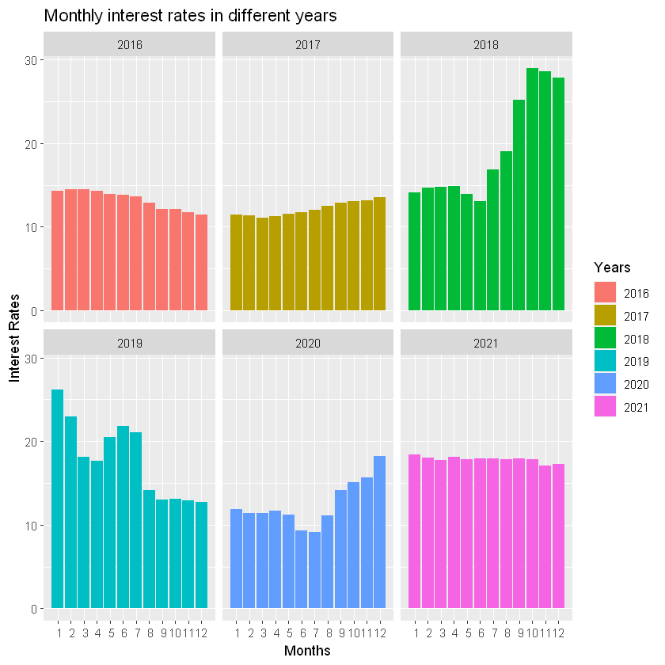

```r
ggplot(konut_kredi_faiz,aes(month_of_date,faiz_oran,fill=factor(year_of_date))) + geom_bar(stat = 'identity') +labs(fill="Years") + facet_wrap(~year_of_date)+scale_x_discrete(limits = c(1:12))+ylab("Interest Rates") + xlab("Months")+
ggtitle("Monthly interest rates in different years")
```

This plots shows us the monthly changes in interest rates. In 2018 and 2019 we can observe the deviations in interest rates and the time that these deviations occured matches with the exchange crisis. Additionall, we observe in 2020 a decrease towards to summer period. It can be interpreted as the promotion of the government to make people buy house easier. However, there is a interesting point in 2021. The interest rates remains stable but number of sellings decreases. It is an interesting point to be examined.

# Cost of Living Index

This index can also effect the total number of sellings. This index shows us the poverty of the people in a country. Therefore, ıt also be examined.

```r
gecinme_index = read.csv("gecinme_index.csv")
setDT(gecinme_index)
gecinme_index[,year_of_date := year(ym(tarih))]
gecinme_index[,month_of_date := month(ym(tarih))]
gecinme_index
```

| tarih | gecinme_index | year_of_date | month_of_date |
| --- | --- | --- | --- |
| 2016-01 | 14062.4 | 2016 | 1 |
| 2016-02 | 14244.0 | 2016 | 2 |
| 2016-03 | 14281.5 | 2016 | 3 |
| 2016-04 | 14435.1 | 2016 | 4 |
| 2016-05 | 14419.6 | 2016 | 5 |
| 2016-06 | 14447.1 | 2016 | 6 |
| 2016-07 | 14574.1 | 2016 | 7 |
| 2016-08 | 14554.1 | 2016 | 8 |
| 2016-09 | 14637.8 | 2016 | 9 |
| 2016-10 | 14814.3 | 2016 | 10 |
| 2016-11 | 14901.9 | 2016 | 11 |
| 2016-12 | 15156.9 | 2016 | 12 |
| 2017-01 | 15407.0 | 2017 | 1 |
| 2017-02 | 15457.9 | 2017 | 2 |
| 2017-03 | 15566.3 | 2017 | 3 |
| 2017-04 | 15743.9 | 2017 | 4 |
| 2017-05 | 15793.1 | 2017 | 5 |
| 2017-06 | 15802.7 | 2017 | 6 |
| 2017-07 | 15833.5 | 2017 | 7 |
| 2017-08 | 15837.2 | 2017 | 8 |
| 2017-09 | 15984.5 | 2017 | 9 |
| 2017-10 | 16295.1 | 2017 | 10 |
| 2017-11 | 16489.5 | 2017 | 11 |
| 2017-12 | 16596.4 | 2017 | 12 |
| 2018-01 | 16740.7 | 2018 | 1 |
| 2018-02 | 16852.5 | 2018 | 2 |
| 2018-03 | 17070.3 | 2018 | 3 |
| 2018-04 | 17354.3 | 2018 | 4 |
| 2018-05 | 17499.7 | 2018 | 5 |
| 2018-06 | 17722.0 | 2018 | 6 |
| ... | ... | ... | ... |
| 2019-07 | 20677.1 | 2019 | 7 |
| 2019-08 | 21199.4 | 2019 | 8 |
| 2019-09 | 21435.3 | 2019 | 9 |
| 2019-10 | 21816.8 | 2019 | 10 |
| 2019-11 | 21914.7 | 2019 | 11 |
| 2019-12 | 22149.3 | 2019 | 12 |
| 2020-01 | 22278.1 | 2020 | 1 |
| 2020-02 | 22530.4 | 2020 | 2 |
| 2020-03 | 22604.2 | 2020 | 3 |
| 2020-04 | 22838.6 | 2020 | 4 |
| 2020-05 | 23332.7 | 2020 | 5 |
| 2020-06 | 23348.3 | 2020 | 6 |
| 2020-07 | 23450.1 | 2020 | 7 |
| 2020-08 | 23589.1 | 2020 | 8 |
| 2020-09 | 23934.8 | 2020 | 9 |
| 2020-10 | 24521.4 | 2020 | 10 |
| 2020-11 | 24997.1 | 2020 | 11 |
| 2020-12 | 25337.7 | 2020 | 12 |
| 2021-01 | 25632.0 | 2021 | 1 |
| 2021-02 | 26012.0 | 2021 | 2 |
| 2021-03 | 26305.1 | 2021 | 3 |
| 2021-04 | 26570.7 | 2021 | 4 |
| 2021-05 | 27015.4 | 2021 | 5 |
| 2021-06 | 27113.1 | 2021 | 6 |
| 2021-07 | 27525.9 | 2021 | 7 |
| 2021-08 | 28044.3 | 2021 | 8 |
| 2021-09 | 28667.7 | 2021 | 9 |
| 2021-10 | 29611.7 | 2021 | 10 |
| 2021-11 | 31007.8 | 2021 | 11 |
| 2021-12 | 33998.8 | 2021 | 12 |

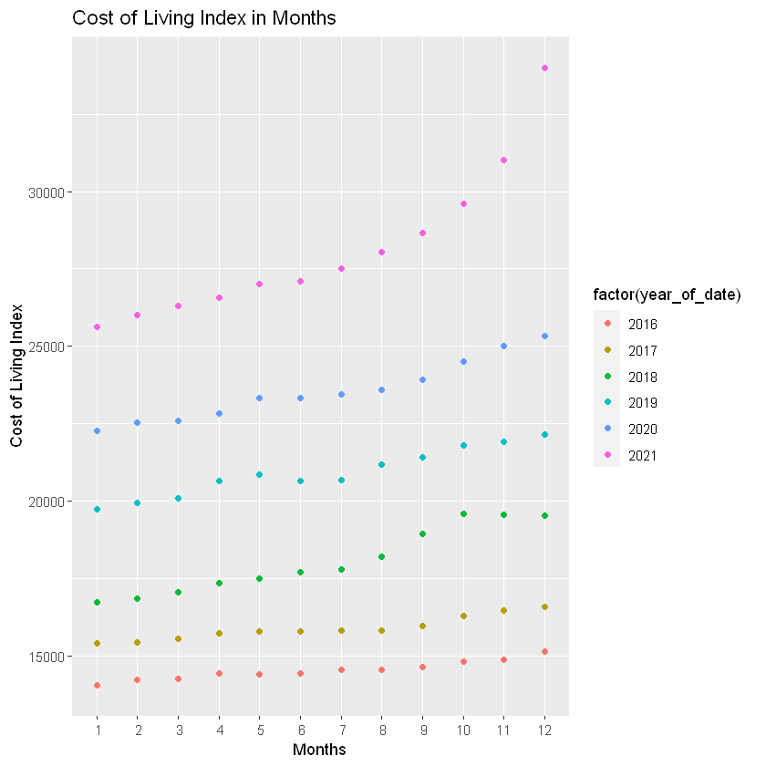

```r
ggplot(gecinme_index,aes(month_of_date,gecinme_index,color=factor(year_of_date))) +
geom_point() + scale_x_discrete(limits = c(1:12)) + ylab("Cost of Living Index") + xlab("Months") + ggtitle("Cost of Living Index in Months")
```

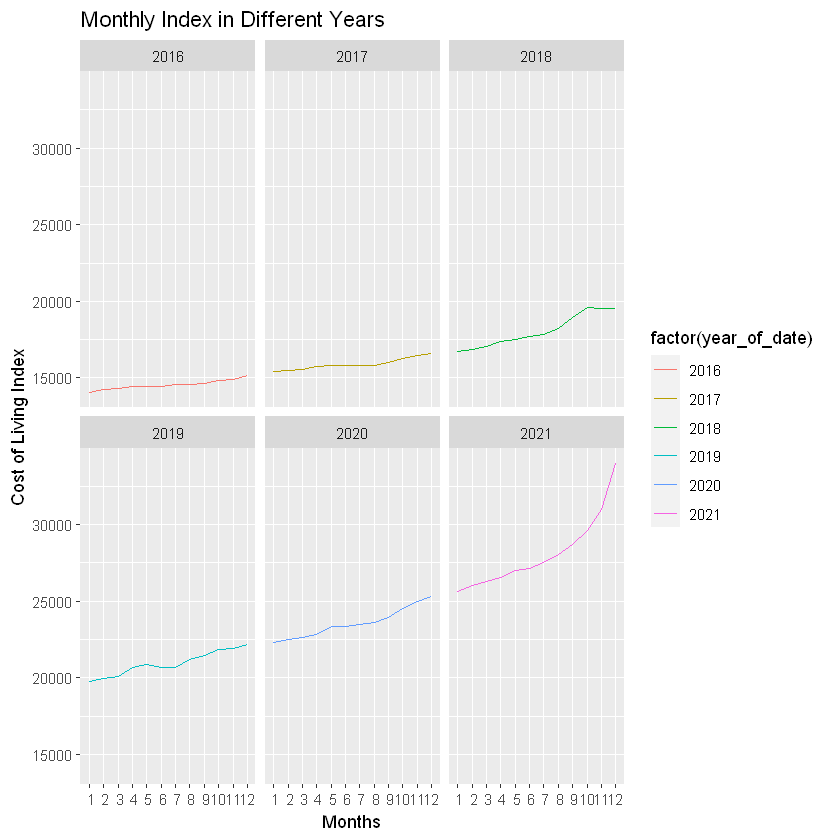

```r
ggplot(gecinme_index,aes(x=month_of_date,y=gecinme_index)) + geom_line(aes(color=factor(year_of_date))) + facet_wrap(~year_of_date) +
scale_x_discrete(limits = c(1:12)) + ylab("Cost of Living Index") + xlab("Months") + ggtitle("Monthly Index in Different Years")
```

# Search Volumes

In this section search volume for the keyword 'satılık ev' is plotted and examined. These graphs can reveal the interests of the people to buy new houses.

```r
house_search = read.csv("satılık_arama.csv")
setDT(house_search)

house_search[,year_of_date := year(ym(tarih))]
house_search[,month_of_date := month(ym(tarih))]
house_search
```

| tarih | arama | year_of_date | month_of_date |
| --- | --- | --- | --- |
| 2016-01 | 27 | 2016 | 1 |
| 2016-02 | 31 | 2016 | 2 |
| 2016-03 | 33 | 2016 | 3 |
| 2016-04 | 31 | 2016 | 4 |
| 2016-05 | 32 | 2016 | 5 |
| 2016-06 | 28 | 2016 | 6 |
| 2016-07 | 32 | 2016 | 7 |
| 2016-08 | 39 | 2016 | 8 |
| 2016-09 | 35 | 2016 | 9 |
| 2016-10 | 35 | 2016 | 10 |
| 2016-11 | 34 | 2016 | 11 |
| 2016-12 | 30 | 2016 | 12 |
| 2017-01 | 34 | 2017 | 1 |
| 2017-02 | 41 | 2017 | 2 |
| 2017-03 | 38 | 2017 | 3 |
| 2017-04 | 34 | 2017 | 4 |
| 2017-05 | 32 | 2017 | 5 |
| 2017-06 | 34 | 2017 | 6 |
| 2017-07 | 41 | 2017 | 7 |
| 2017-08 | 37 | 2017 | 8 |
| 2017-09 | 35 | 2017 | 9 |
| 2017-10 | 33 | 2017 | 10 |
| 2017-11 | 32 | 2017 | 11 |
| 2017-12 | 32 | 2017 | 12 |
| 2018-01 | 33 | 2018 | 1 |
| 2018-02 | 35 | 2018 | 2 |
| 2018-03 | 34 | 2018 | 3 |
| 2018-04 | 32 | 2018 | 4 |
| 2018-05 | 34 | 2018 | 5 |
| 2018-06 | 32 | 2018 | 6 |
| ... | ... | ... | ... |
| 2019-07 | 35 | 2019 | 7 |
| 2019-08 | 45 | 2019 | 8 |
| 2019-09 | 40 | 2019 | 9 |
| 2019-10 | 38 | 2019 | 10 |
| 2019-11 | 35 | 2019 | 11 |
| 2019-12 | 36 | 2019 | 12 |
| 2020-01 | 43 | 2020 | 1 |
| 2020-02 | 41 | 2020 | 2 |
| 2020-03 | 33 | 2020 | 3 |
| 2020-04 | 36 | 2020 | 4 |
| 2020-05 | 59 | 2020 | 5 |
| 2020-06 | 100 | 2020 | 6 |
| 2020-07 | 74 | 2020 | 7 |
| 2020-08 | 71 | 2020 | 8 |
| 2020-09 | 52 | 2020 | 9 |
| 2020-10 | 48 | 2020 | 10 |
| 2020-11 | 43 | 2020 | 11 |
| 2020-12 | 40 | 2020 | 12 |
| 2021-01 | 46 | 2021 | 1 |
| 2021-02 | 44 | 2021 | 2 |
| 2021-03 | 42 | 2021 | 3 |
| 2021-04 | 41 | 2021 | 4 |
| 2021-05 | 48 | 2021 | 5 |
| 2021-06 | 48 | 2021 | 6 |
| 2021-07 | 49 | 2021 | 7 |
| 2021-08 | 49 | 2021 | 8 |
| 2021-09 | 44 | 2021 | 9 |
| 2021-10 | 43 | 2021 | 10 |
| 2021-11 | 44 | 2021 | 11 |
| 2021-12 | 46 | 2021 | 12 |

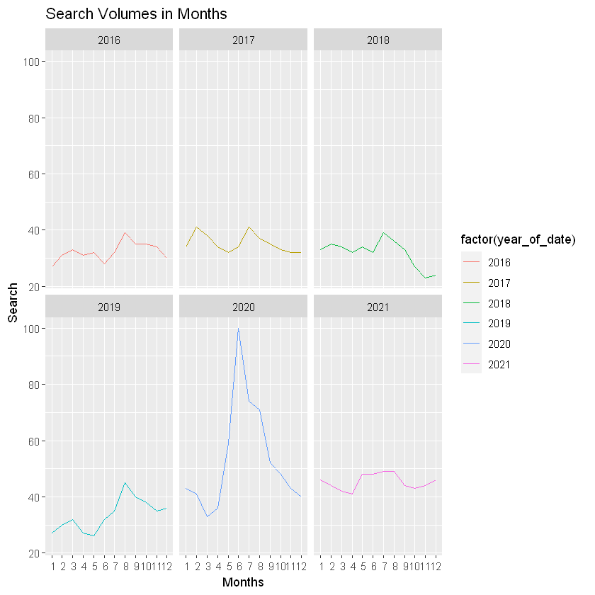

```r
ggplot(house_search,aes(x=month_of_date,y=arama)) +geom_line(aes(color=factor(year_of_date))) + facet_wrap(~year_of_date)+ylab("Search") +xlab("Months")+scale_x_discrete(limits = c(1:12))+
ggtitle("Search Volumes in Months")
```

These graphs are consistent with our seasonality assumption. In every summer of different years, search volumes increase and then decreases like our data. Also, in 2020 there is huge volume which also corresponds to the huge increase in sold houses.

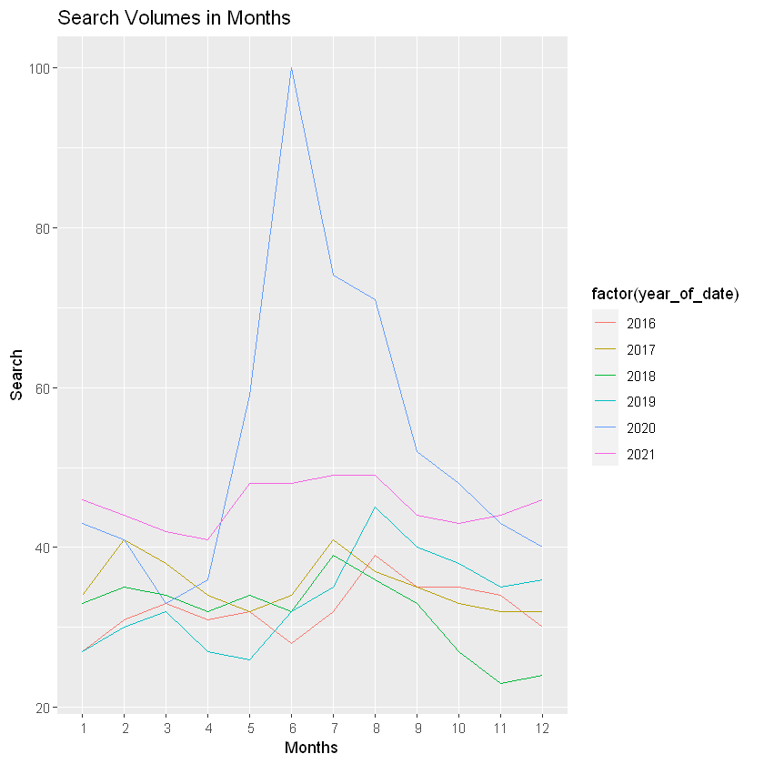

```r
ggplot(house_search,aes(month_of_date,arama,color=factor(year_of_date))) + geom_line() + scale_x_discrete(limits = c(1:12))+
ylab("Search") +xlab("Months") + ggtitle("Search Volumes in Months")
```

This plot is a different represantation of the monthly data. A key point is again the 2020 6th month value. There is huge and obvious difference. It is probably related with Covid-19. It can be because of the government regulations or people's psychology. In this era, awareness to the value of houses can be increased.

# Correlation Between Indicators

It can be good idea to see the correlation between indicators to test our hypothesis.

```r
library(corrplot)
data_table_summary = data.table(date=sold_house_data$tarih,sold_house=sold_house_data$toplam_satış,interest_rate=konut_kredi_faiz$faiz_oran,cost_of_living_index = gecinme_index$gecinme_index,search_volume = house_search$arama)
data_table_summary[,month_of_date := month(ym(date))]
data_table_summary[,year_of_date := month(ym(date))]
data_table_summary
```

| date | sold_house | interest_rate | cost_of_living_index | search_volume | month_of_date | year_of_date |
| --- | --- | --- | --- | --- | --- | --- |
| 2016-01 | 40077 | 14.27 | 14062.4 | 27 | 1 | 1 |
| 2016-02 | 47409 | 14.45 | 14244.0 | 31 | 2 | 2 |
| 2016-03 | 52374 | 14.45 | 14281.5 | 33 | 3 | 3 |
| 2016-04 | 46908 | 14.33 | 14435.1 | 31 | 4 | 4 |
| 2016-05 | 56043 | 13.96 | 14419.6 | 32 | 5 | 5 |
| 2016-06 | 49354 | 13.84 | 14447.1 | 28 | 6 | 6 |
| 2016-07 | 37829 | 13.67 | 14574.1 | 32 | 7 | 7 |
| 2016-08 | 53784 | 12.86 | 14554.1 | 39 | 8 | 8 |
| 2016-09 | 50972 | 12.09 | 14637.8 | 35 | 9 | 9 |
| 2016-10 | 61677 | 12.12 | 14814.3 | 35 | 10 | 10 |
| 2016-11 | 63467 | 11.69 | 14901.9 | 34 | 11 | 11 |
| 2016-12 | 71792 | 11.42 | 15156.9 | 30 | 12 | 12 |
| 2017-01 | 44235 | 11.45 | 15407.0 | 34 | 1 | 1 |
| 2017-02 | 45215 | 11.38 | 15457.9 | 41 | 2 | 2 |
| 2017-03 | 56376 | 11.06 | 15566.3 | 38 | 3 | 3 |
| 2017-04 | 51988 | 11.28 | 15743.9 | 34 | 4 | 4 |
| 2017-05 | 52976 | 11.55 | 15793.1 | 32 | 5 | 5 |
| 2017-06 | 45433 | 11.72 | 15802.7 | 34 | 6 | 6 |
| 2017-07 | 53949 | 12.02 | 15833.5 | 41 | 7 | 7 |
| 2017-08 | 56498 | 12.49 | 15837.2 | 37 | 8 | 8 |
| 2017-09 | 70019 | 12.87 | 15984.5 | 35 | 9 | 9 |
| 2017-10 | 56994 | 13.05 | 16295.1 | 33 | 10 | 10 |
| 2017-11 | 59354 | 13.12 | 16489.5 | 32 | 11 | 11 |
| 2017-12 | 66661 | 13.52 | 16596.4 | 32 | 12 | 12 |
| 2018-01 | 44363 | 14.14 | 16740.7 | 33 | 1 | 1 |
| 2018-02 | 43713 | 14.68 | 16852.5 | 35 | 2 | 2 |
| 2018-03 | 50701 | 14.79 | 17070.3 | 34 | 3 | 3 |
| 2018-04 | 47534 | 14.83 | 17354.3 | 32 | 4 | 4 |
| 2018-05 | 55502 | 13.88 | 17499.7 | 34 | 5 | 5 |
| 2018-06 | 57064 | 13.10 | 17722.0 | 32 | 6 | 6 |
| ... | ... | ... | ... | ... | ... | ... |
| 2019-07 | 38931 | 21.06 | 20677.1 | 35 | 7 | 7 |
| 2019-08 | 40634 | 14.15 | 21199.4 | 45 | 8 | 8 |
| 2019-09 | 51393 | 12.98 | 21435.3 | 40 | 9 | 9 |
| 2019-10 | 50181 | 13.12 | 21816.8 | 38 | 10 | 10 |
| 2019-11 | 48909 | 12.96 | 21914.7 | 35 | 11 | 11 |
| 2019-12 | 75480 | 12.69 | 22149.3 | 36 | 12 | 12 |
| 2020-01 | 36040 | 11.88 | 22278.1 | 43 | 1 | 1 |
| 2020-02 | 37303 | 11.43 | 22530.4 | 41 | 2 | 2 |
| 2020-03 | 34089 | 11.40 | 22604.2 | 33 | 3 | 3 |
| 2020-04 | 14848 | 11.72 | 22838.6 | 36 | 4 | 4 |
| 2020-05 | 16860 | 11.23 | 23332.7 | 59 | 5 | 5 |
| 2020-06 | 58632 | 9.30 | 23348.3 | 100 | 6 | 6 |
| 2020-07 | 67937 | 9.11 | 23450.1 | 74 | 7 | 7 |
| 2020-08 | 52123 | 11.09 | 23589.1 | 71 | 8 | 8 |
| 2020-09 | 41376 | 14.16 | 23934.8 | 52 | 9 | 9 |
| 2020-10 | 36976 | 15.07 | 24521.4 | 48 | 10 | 10 |
| 2020-11 | 36658 | 15.68 | 24997.1 | 43 | 11 | 11 |
| 2020-12 | 36898 | 18.19 | 25337.7 | 40 | 12 | 12 |
| 2021-01 | 22268 | 18.39 | 25632.0 | 46 | 1 | 1 |
| 2021-02 | 24737 | 17.99 | 26012.0 | 44 | 2 | 2 |
| 2021-03 | 33365 | 17.74 | 26305.1 | 42 | 3 | 3 |
| 2021-04 | 29212 | 18.13 | 26570.7 | 41 | 4 | 4 |
| 2021-05 | 18204 | 17.84 | 27015.4 | 48 | 5 | 5 |
| 2021-06 | 40092 | 17.90 | 27113.1 | 48 | 6 | 6 |
| 2021-07 | 32672 | 17.93 | 27525.9 | 49 | 7 | 7 |
| 2021-08 | 42639 | 17.86 | 28044.3 | 49 | 8 | 8 |
| 2021-09 | 43967 | 17.90 | 28667.7 | 44 | 9 | 9 |
| 2021-10 | 41914 | 17.82 | 29611.7 | 43 | 10 | 10 |
| 2021-11 | 55706 | 17.10 | 31007.8 | 44 | 11 | 11 |
| 2021-12 | 76747 | 17.31 | 33998.8 | 46 | 12 | 12 |

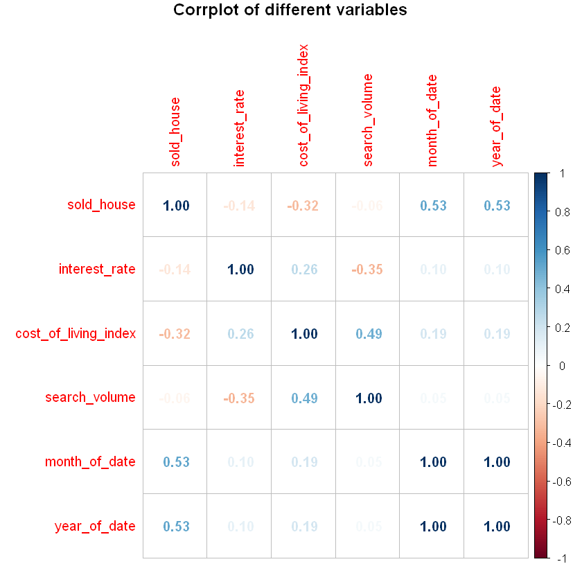

```r
corrplot(cor(data_table_summary[,c(2:7)]),method="number",title = "Corrplot of different variables",mar=c(0,0,1,0))
```

This plot shows us the relationships between variables and when we check the first row we can understand the effects of the variables to number of sold houses. Here, we see that interest rates and cost of living index have negative correlations which mean their relationships are inversed. İf interest rate of cost of living ındex increases, our number of sellings decreases. Interestingly, correlation between search_volumes are almost zero with a negative sign.

# Conclusion

# References

All data releated number of selling, index and interest rates is driven from Electronic Data Delivery System(https://evds2.tcmb.gov.tr/) and search volume data is driven from Google Trends(https://trends.google.com/trends/)